# Web Mining and Applied NLP (44-620)

## Web Scraping and NLP with Requests, BeautifulSoup, and spaCy

### Student Name: Michael Pogue

Perform the tasks described in the Markdown cells below. When you have completed the assignment make sure your code cells have all been run (and have output beneath them) and ensure you have committed and pushed ALL of your changes to your assignment repository.

Every question that requires you to write code will have a code cell underneath it; you may either write your entire solution in that cell or write it in a python file (`.py`), then import and run the appropriate code to answer the question.

# Question 1.

Write code that extracts the article html from https://web.archive.org/web/20210327165005/https://hackaday.com/2021/03/22/how-laser-headlights-work/ and dumps it to a .pkl (or other appropriate file)

```python
# Import Modules
import requests
from bs4 import BeautifulSoup, SoupStrainer
import pickle
import spacy
from spacytextblob.spacytextblob import SpacyTextBlob
from collections import Counter
from matplotlib import pyplot as plt
from matplotlib import style

# List declarative elements
parser = 'html.parser'
nlp = spacy.load('en_core_web_sm')
nlp.add_pipe('spacytextblob')

# Aquire Data
article_page = requests.get('https://web.archive.org/web/20210327165005/https://hackaday.com/2021/03/22/how-laser-headlights-work/')
article_html = article_page.text

with open('laser_headlights.pkl', 'wb') as f:
    pickle.dump(article_page.text, f)
```

# Question 2.

Read in your article's html source from the file you created in question 1 and print it's text (use `.get_text()`)

```python
with open('laser_headlights.pkl', 'rb') as f:
    article_html = pickle.load(f)

soup = BeautifulSoup(article_html, parser)
article_element = soup.find('article')

print(article_element.get_text())
```

```
How Laser Headlights Work


                130 Comments

by:
Lewin Day



March 22, 2021








When we think about the onward march of automotive technology, headlights aren’t usually the first thing that come to mind. Engines, fuel efficiency, and the switch to electric power are all more front of mind. However, that doesn’t mean there aren’t thousands of engineers around the world working t…
Sealed beam headlights gave way to more modern designs once regulations loosened up, while bulbs moved from simple halogens to xenon HIDs and, more recently, LEDs. Now, a new technology is on the scene, with lasers!

Laser Headlights?!
BWM’s prototype laser headlight assemblies undergoing testing.
The first image brought to mind by the phrase “laser headlights” is that of laser beams firing out the front of an automobile. Obviously, coherent beams of monochromatic light would make for poor illumination outside of a very specific spot quite some distance away. Thankfully for our eyes, laser he…
Instead, laser headlights consist of one or more solid state laser diodes mounted inside the headlight. These blue lasers are fired at a yellow phosphor, similar to that used in white LEDs. This produces a powerful, vibrant white light that can then be bounced off reflectors and out of the headlight…
BWM’s futuristic i8 was one of the first vehicles to ship with laser headlight technology.
Laser headlights are still a nascent technology, thus far only appearing in a few BMW, Audi, and other select vehicles. BMW’s technology was developed in partnership with lighting experts OSRAM. In practice, a regular LED low-beam lamp is used, with the laser used to create an incredibly bright and …
Tearing Down the Laser Headlight
A marketing image showing the construction of an aftermarket LED/laser headlight. We’d take the laser power with a grain of salt — it’s difficult to imagine a 10 W laser shining directly on some small LEDs without melting a hole through the board in short order.
An aftermarket has sprung up too, with delightfully innovative designs. Combined laser/LED headlights are readily available on Alibaba, designed as a drop in replacement for projector lamps on existing vehicles. These often use an LED low-beam, and a combined LED/laser high beam, where the laser dio…
However, [mikeselectricstuff] has happened to lay his hands on both the BMW and aftermarket parts, tearing them all down in his workshop to see what makes them tick. The differences are multitude when laid bare on the bench. The AliExpress part is relatively simple, wired up no differently from a re…
Where the aftermarket part is a little out of left field, the BMW design is another thing entirely. The cutting-edge headlights are hooked up with multiple connectors and over 30 conductors, with much of the driver electronics living in an external controller. Much of this is to drive the various LE…
Cost Versus Performance
Despite the efficiency gains available, the technology remains expensive. Powerful laser diodes don’t come cheap, after all. However, as the technology trickles down to lower-end models, it’s likely that we could see economies of scale change that for the better. Indeed, if national authorities begi…
The high light output of laser headlights in a compact package allows engineers greater freedom when designing the front-end of a car.
As it currently stands, much of the appeal of the new technology is about the packaging benefits, which allow automotive designers greater freedom around the headlight area. Such concerns are less of a factor when it comes to light fittings in the home or office, or indeed, on lower-end automobiles.…



```

[output cut: 8 more lines]

```














Posted in car hacks, Engineering, Featured, Laser Hacks, SliderTagged laser, laser headlight, laser headlights, light
```

# Question 3.

Load the article text into a trained `spaCy` pipeline, and determine the 5 most frequent tokens (converted to lower case). Print the common tokens with an appropriate label. Additionally, print the tokens their frequencies (with appropriate labels). Make sure to remove things we don't care about (punctuation, stopwords, whitespace).

```python
article_text = article_element.get_text()
doc = nlp(article_element.get_text())

def token_isolation(token):
    return not (token.is_space or token.is_punct or token.is_stop)

interesting_tokens = [token for token in doc if token_isolation(token)]
word_freq = Counter(map(str,interesting_tokens))
print(f'Most common words and their frequencies: \n{word_freq.most_common(5)}')
```

```
Most common words and their frequencies:
[('laser', 29), ('headlights', 17), ('technology', 10), ('headlight', 10), ('LED', 10)]
```

# Question 4.

Load the article text into a trained `spaCy` pipeline, and determine the 5 most frequent lemmas (converted to lower case). Print the common lemmas with an appropriate label. Additionally, print the lemmas with their frequencies (with appropriate labels). Make sure to remove things we don't care about (punctuation, stopwords, whitespace).

```python
interesting_lemmas = [token.lemma_ for token in doc if token_isolation(token)]
lemma_freq = Counter(interesting_lemmas)
print(f"Most common lemma's and their frequencies: \n{lemma_freq.most_common(5)}")
```

```
Most common lemma's and their frequencies:
[('laser', 34), ('headlight', 27), ('beam', 12), ('led', 11), ('technology', 10)]
```

# Question 5.

Define the following methods:

```
* `score_sentence_by_token(sentence, interesting_token)` that takes a sentence and a list of interesting token and returns the number of times that any of the interesting words appear in the sentence divided by the number of words in the sentence
* `score_sentence_by_lemma(sentence, interesting_lemmas)` that takes a sentence and a list of interesting lemmas and returns the number of times that any of the interesting lemmas appear in the sentence divided by the number of words in the sentence
```

You may find some of the code from the in class notes useful; feel free to use methods (rewrite them in this cell as well). Test them by showing the score of the first sentence in your article using the frequent tokens and frequent lemmas identified in question 3.

```python
sentences = list(doc.sents)

def trim_extra(token):
    return not (token.is_space or token.is_punct or token.is_stop)

# Find Tokens
interesting_token = [token for token in doc if trim_extra(token)]
token_freq = Counter(interesting_token)
interesting_lemmas = [token.lemma_.lower() for token in doc if trim_extra(token)]
lemma_freq = Counter(interesting_lemmas)

# Pick most common
top_tok = set()
for tok, freq in token_freq.most_common(5):
    top_tok.add(tok)

top_lem = set()
for lem, freq in lemma_freq.most_common(5):
    top_lem.add(lem)

# Seperate paragraph into lines
for sentence in sentences:
    count = 0
    for token in sentence:
        if token.lemma_.lower() in interesting_lemmas:
            count += 1
    sent_str = str(sentence).replace('\n','').replace('  ',' ')
    #print(count,':', sent_str)

sentence = sentences[1]
print(sentence)

def score_sentence_by_token(sentence, interesting_tokens):
    # Word Count
    count = 0
    for token in sentence:
        if not (token.is_space or token.is_punct):
            count += 1

    # Word occurrence count
    #occurrence = 0
    occurrence =  len([i for i in interesting_tokens if i in sentence ])

    # Calculation
    result = occurrence / count
    return result, count, occurrence

def score_sentence_by_lemma(sentence, interesting_lemmas):
    # Word Count
    count = 0
    for token in sentence:
        if not (token.is_space or token.is_punct):
            count += 1

    # Word occurrence count
    lemcount = 0
    for token in sentence:
        if token.lemma_.lower() in top_lem:
            lemcount += 1

    # Calculation
    result = lemcount / count
    return result, count, lemcount

result_token = score_sentence_by_token(sentence, interesting_token)
result_lemma = score_sentence_by_lemma(sentence, interesting_lemmas)

# print(sentence)
print(f'\nSentences By Tokens: \nOccurrence of tokens in sentence: {result_token[2]} \nWord count of sentence: {result_token[1]} \nDivided Results: {round(result_token[0], 4)}')
print(f'\nSentences By Lemmas: \nOccurrence of lemmas in sentence: {result_lemma[2]} \nWord count of sentence: {result_lemma[1]} \nDivided Results: {round(result_lemma[0], 4)}')
```

```
When we think about the onward march of automotive technology, headlights aren’t usually the first thing that come to mind.

Sentences By Tokens:
Occurrence of tokens in sentence: 10
Word count of sentence: 21
Divided Results: 0.4762

Sentences By Lemmas:
Occurrence of lemmas in sentence: 2
Word count of sentence: 21
Divided Results: 0.0952
```

# Question 6.

Make a list containing the scores (using tokens) of every sentence in the article, and plot a histogram with appropriate titles and axis labels of the scores. From your histogram, what seems to be the most common range of scores (put the answer in a comment after your code)?

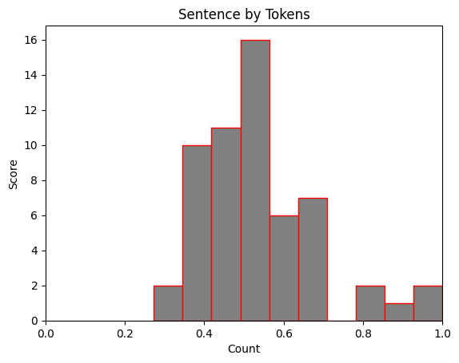

```python
# Token per Sentence
sentence = sentences[0]
tok_score_list = []
for sentence in sentences:
    tok_score_list.append(score_sentence_by_token(sentence, interesting_token)[0])
x_toc = tok_score_list

# Histogram
plt.title("Sentence by Tokens")
plt.xlabel("Count")
plt.ylabel("Score")
plt.xlim(0, 1)
#plt.ylim(,)
plt.hist(x_toc, edgecolor = 'red', facecolor = 'grey')
plt.show()
```

# Question 7.

Make a list containing the scores (using lemmas) of every sentence in the article, and plot a histogram with appropriate titles and axis labels of the scores. From your histogram, what seems to be the most common range of scores (put the answer in a comment after your code)?

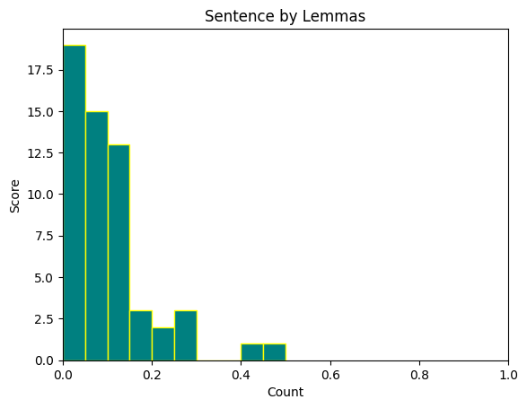

```python
# Lemma per Sentence
sentence = sentences[0]
lem_score_list = []
for sentence in sentences:
    lem_score_list.append(score_sentence_by_lemma(sentence, interesting_lemmas)[0])
x_lem = lem_score_list

# Histogram
plt.title("Sentence by Lemmas")
plt.xlabel("Count")
plt.ylabel("Score")
plt.xlim(0, 1)
#plt.ylim(,)
plt.hist(x_lem, edgecolor = 'yellow', facecolor = 'teal')
plt.show()
```

# Question 8.

Which tokens and lexems would be ommitted from the lists generated in questions 3 and 4 if we only wanted to consider nouns as interesting words? How might we change the code to only consider nouns? Put your answer in this Markdown cell (you can edit it by double clicking it).

Not much would change. "technology" would be out and "light" would fill the missing spot in the top 5. I would add the spacy "noun_chunks" to my for loop along with getting rid of spaces.